# SME0828 - Introdução à Ciência de Dados

# Projeto 1: Preparação e transformação dos dados

### Alunos

Aline Fernanda da Conceição, Nº USP: 9437275

Breno Lívio Silva de Almeida, Nº USP: 10276675

Matheus Victal Cerqueira, Nº USP: 10276661

*Universidade de São Paulo, São Carlos, Brasil.*

## Exercícios sugeridos para a atividade avaliativa 1

Os seguintes exercícios foram sugeridos para entrega em 21 de setembro de 2020 para a disciplina SME0828 oferecida pelo Instituto de Ciências Matemáticas e de Computação (ICMC) da Universidade de São Paulo (USP), a qual foi ministrada pelo professor Francisco Aparecido Rodrigues. Tal atividade visa aplicar diferentes técnicas de preparação de dados em Python com o intuito de deixá-los mais suscetíveis a análises estatísticas e computacionais. O conjunto de dados que será mais utilizado é o famoso conjunto [Iris](https://pt.wikipedia.org/wiki/Conjunto_de_dados_flor_Iris#Conjunto_de_dados).

## Desenvolvimento

### 1 - Leia os dados com erro novamente, faça a limpeza e remova as duas últimas colunas.

Lendo dataset "Iris with errors" no formato CSV, colocando em um dataframe

```python
import pandas as pd

# Ler arquivo CSV
irisErrors1 = pd.read_csv('https://raw.githubusercontent.com/BrenoUSP/SME0828_DataScience/master/Projects/data/iris-with-errors.csv', header=(0))
```

Limpa os dados removendo linhas duplicadas e linhas com np.NaN

```python
import numpy as np

# Remove linhas duplicadas
irisErrors1 = irisErrors1.drop_duplicates()

# Subtitui caractere por NaN
irisErrors1 = irisErrors1.replace('?', np.nan)

# Remove as linhas com Nan
irisErrors1 = irisErrors1.dropna()
```

Remove as duas últimas colunas do data frame e mostra sua versão final

```python
irisErrors1 = irisErrors1.drop(irisErrors1.columns[[-2, -1]], axis = 1)

irisErrors1
```

|  | sepal_length | sepal_width | petal_length |
| --- | --- | --- | --- |
| 0 | 5.1 | 3.5 | 1.4 |
| 3 | 4.7 | 3.2 | 1.3 |
| 6 | 5 | 3.6 | 1.4 |
| 7 | 5.4 | 3.9 | 1.7 |
| 10 | 5 | 3.4 | 1.5 |
| 11 | 4.4 | 2.9 | 1.4 |
| 12 | 4.9 | 3.1 | 1.5 |
| 13 | 5.4 | 3.7 | 1.5 |
| 15 | 4.8 | 3.4 | 1.6 |
| 16 | 4.8 | 3 | 1.4 |
| 18 | 4.3 | 3 | 1.1 |
| 19 | 5.8 | 4 | 1.2 |
| 20 | 5.7 | 4.4 | 1.5 |
| 22 | 5.1 | 3.5 | 1.4 |

### 2 - Leia os dados com erro novamente e insira a mediana de cada atributo onde for encontrada NaN.

Lendo dataset "Iris with errors" no formato CSV, colocando em um dataframe

```python
import pandas as pd

# CSV file
irisErrors2 = pd.read_csv('https://raw.githubusercontent.com/BrenoUSP/SME0828_DataScience/master/Projects/data/iris-with-errors.csv', header=(0))
```

Substitui valores com '?' por np.NaN

```python
import numpy as np

irisErrors2 = irisErrors2.replace('?', np.nan)
```

Convertemos para o formato Numpy e ignoramos a última coluna (classe)

```python
arrIrisErrors = np.array(irisErrors2[irisErrors2.columns[0:irisErrors2.shape[1]-1]], dtype = float)
```

Usamos a função nanmedian que calcula a mediana ignorando os valores NaN. Calculamos a mediana de cada atributo e armazenamos em um vetor.

```python
medians = np.nanmedian(arrIrisErrors, axis = 0)
```

Pega os valores das medianas no vetor e coloca na posição que corresponderia no array. Utilizamos a função [nanmedian](https://numpy.org/doc/stable/reference/generated/numpy.median.html).

```python
for i in np.arange(0, arrIrisErrors.shape[0]):
    for j in np.arange(0, arrIrisErrors.shape[1]):
        if(np.isnan(arrIrisErrors[i,j]) == True): # verificar se é uma entrada com Nan
           arrIrisErrors[i,j] = medians[j] # insere a mediana

arrIrisErrors
```

```
array([[5.1 , 3.5 , 1.4 , 0.2 ],
       [5.1 , 3.5 , 1.4 , 0.2 ],
       [5.05, 3.  , 1.4 , 0.2 ],
       [4.7 , 3.2 , 1.3 , 0.2 ],
       [5.1 , 3.5 , 1.4 , 0.2 ],
       [5.05, 3.1 , 1.5 , 0.2 ],
       [5.  , 3.6 , 1.4 , 0.2 ],
       [5.4 , 3.9 , 1.7 , 0.4 ],
       [5.4 , 3.9 , 1.7 , 0.4 ],
       [4.6 , 3.4 , 1.4 , 0.2 ],
       [5.  , 3.4 , 1.5 , 0.2 ],
       [4.4 , 2.9 , 1.4 , 0.2 ],
       [4.9 , 3.1 , 1.5 , 0.1 ],
       [5.4 , 3.7 , 1.5 , 0.2 ],
       [4.4 , 2.9 , 1.4 , 0.2 ],
       [4.8 , 3.4 , 1.6 , 0.2 ],
       [4.8 , 3.  , 1.4 , 0.1 ],
       [4.4 , 2.9 , 1.4 , 0.2 ],
       [4.3 , 3.  , 1.1 , 0.1 ],
       [5.8 , 4.  , 1.2 , 0.2 ],
       [5.7 , 4.4 , 1.5 , 0.4 ],
       [5.4 , 3.9 , 1.3 , 0.2 ],
       [5.1 , 3.5 , 1.4 , 0.3 ],
       [5.7 , 3.45, 1.7 , 0.3 ],
       [5.05, 3.8 , 1.5 , 0.3 ]])
```

### 3 - Considere os dados da Iris e mostre a distribuição de probabilidades de cada uma das variáveis após a normalização e padronização.

Leitura de csv do dataset "Iris" como Data Frame

```python
import pandas as pd

data = pd.read_csv('https://raw.githubusercontent.com/brenoslivio/SME0828_DataScience/master/Projects/data/iris.csv', header=(0))
```

##### Normalização dos dados

```python
import numpy as np
from sklearn.preprocessing import MinMaxScaler

# considera somente os atributos, ignorando a última coluna, que contem a classe
X = np.array(data[data.columns[0:data.shape[1]-1]])

# prepara a função para transformar os dados
scaler = MinMaxScaler(feature_range=(0, 1))

# Realiza a normalização e coloca em um novo vetor
X_norm = scaler.fit_transform(X)
```

Para estudar a distribuição de probabilidades de cada uma das variáveis após normalização e padronização, será utilizada a função distplot() da biblioteca Seaborn. Abaixo, tem-se os histogramas para o conjunto de dados após a normalização entre 0 e 1. Obs.: para criar-se o número de bins nos histogramas abaixo, foi utilizada a regra de sturges, a qual é muito utilizada em estatística para definir o número de classes com o intuito de criar-se um histograma de frequências. Esta [página](https://pt.wikipedia.org/wiki/Histograma#Escolha_do_n%C3%BAmero_de_barras_pela_f%C3%B3rmula_de_Sturges) da wikipédia aborda a regra aqui discutida.

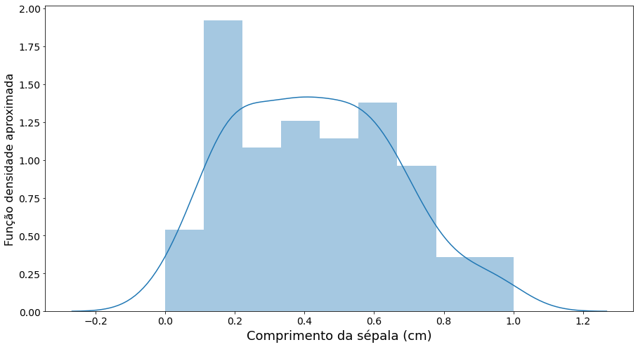

```python
import warnings
import matplotlib.pyplot as plt
import seaborn as sns

warnings.filterwarnings("ignore")
plt.figure(figsize=(15, 8))
x1 = sns.distplot(X_norm[:,0], bins = 'sturges', norm_hist = False, kde = True)
plt.xlabel('Comprimento da sépala (cm)', fontsize=18)
plt.ylabel('Função densidade aproximada', fontsize=16)
plt.xticks(fontsize=14)
plt.yticks(fontsize=14)
plt.show(True)
```

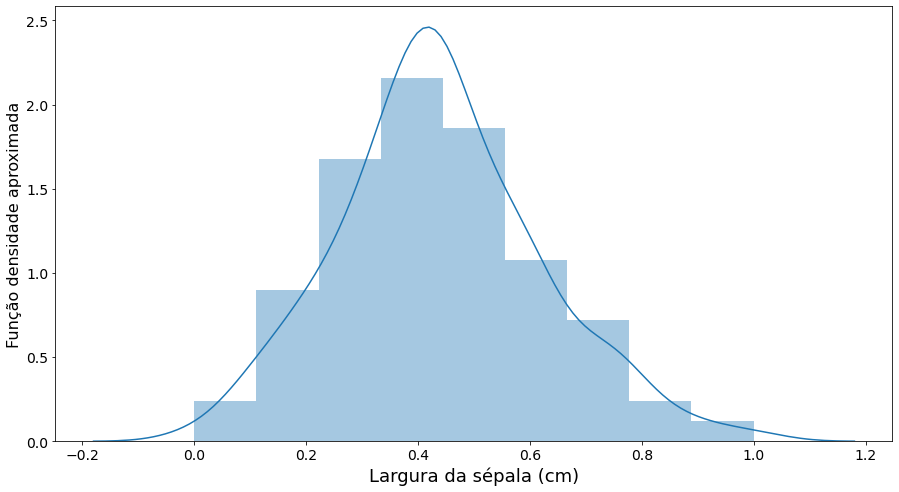

```python
plt.figure(figsize=(15, 8))
x2 = sns.distplot(X_norm[:,1], bins = 'sturges')
plt.xlabel('Largura da sépala (cm)', fontsize=18)
plt.ylabel('Função densidade aproximada', fontsize=16)
plt.xticks(fontsize=14)
plt.yticks(fontsize=14)
plt.show(True)
```

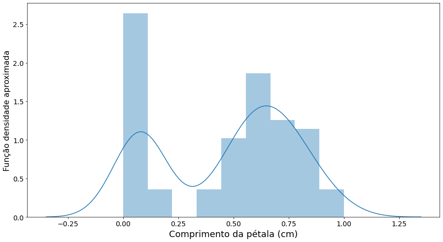

```python
plt.figure(figsize=(15, 8))
x3 = sns.distplot(X_norm[:,2], bins = 'sturges')
plt.xlabel('Comprimento da pétala (cm)', fontsize=18)
plt.ylabel('Função densidade aproximada', fontsize=16)
plt.xticks(fontsize=14)
plt.yticks(fontsize=14)
plt.show(True)
```

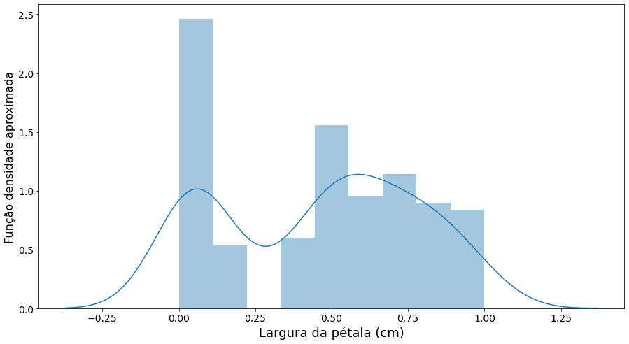

```python
plt.figure(figsize=(15, 8))
x4 = sns.distplot(X_norm[:,3], bins = 'sturges')
plt.xlabel('Largura da pétala (cm)', fontsize=18)
plt.ylabel('Função densidade aproximada', fontsize=16)
plt.xticks(fontsize=14)
plt.yticks(fontsize=14)
plt.show(True)
```

Abaixo, plotou-se todas as distribuções em um mesmo gráfico

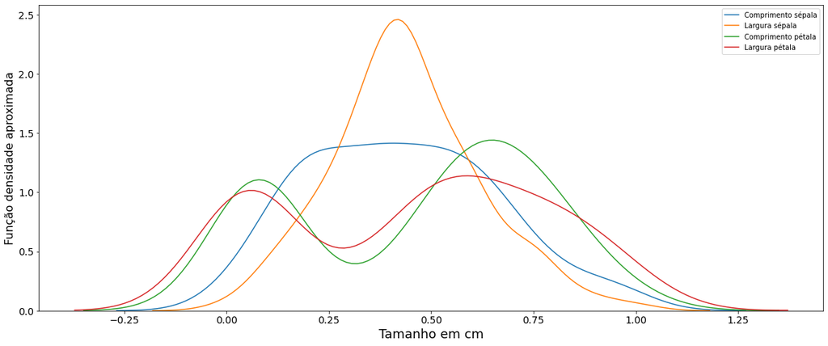

```python
plt.figure(figsize=(20, 8))

x1 = sns.distplot(X_norm[:,0], bins = 'sturges',hist = False, label = "Comprimento sépala")
x2 = sns.distplot(X_norm[:,1], bins = 'sturges',hist = False, label = "Largura sépala")
x3 = sns.distplot(X_norm[:,2], bins = 'sturges',hist = False, label = "Comprimento pétala")
x4 = sns.distplot(X_norm[:,3], bins = 'sturges',hist = False, label = "Largura pétala")

plt.xlabel('Tamanho em cm', fontsize=18)
plt.ylabel('Função densidade aproximada', fontsize=16)
plt.xticks(fontsize=14)
plt.yticks(fontsize=14)
plt.show(True)
```

##### Padronização dos dados

Agora, padronizemos o conjunto de dados e façamos o mesmo procedimento que o realizado acima:

```python
from sklearn.preprocessing import StandardScaler

X = np.array(data[data.columns[0:data.shape[1]-1]])

# prepara a função para transformar os dados
scaler = StandardScaler().fit(X)

# realiza a padronização (média=0, variância = 1)
rescaledX = scaler.transform(X)
```

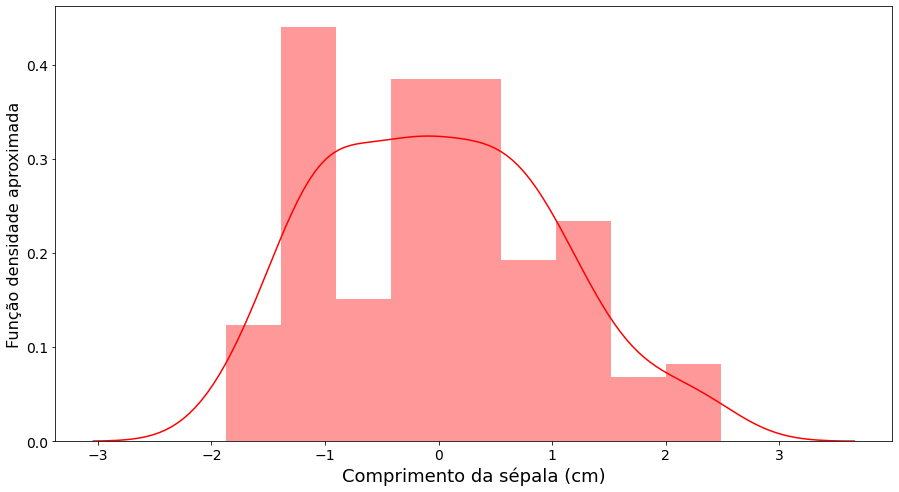

```python
import warnings
warnings.filterwarnings("ignore")
plt.figure(figsize=(15, 8))
x1 = sns.distplot(rescaledX[:,0], bins = 'sturges', norm_hist = False, kde = True, color = "r")
plt.xlabel('Comprimento da sépala (cm)', fontsize=18)
plt.ylabel('Função densidade aproximada', fontsize=16)
plt.xticks(fontsize=14)
plt.yticks(fontsize=14)
plt.show(True)
```

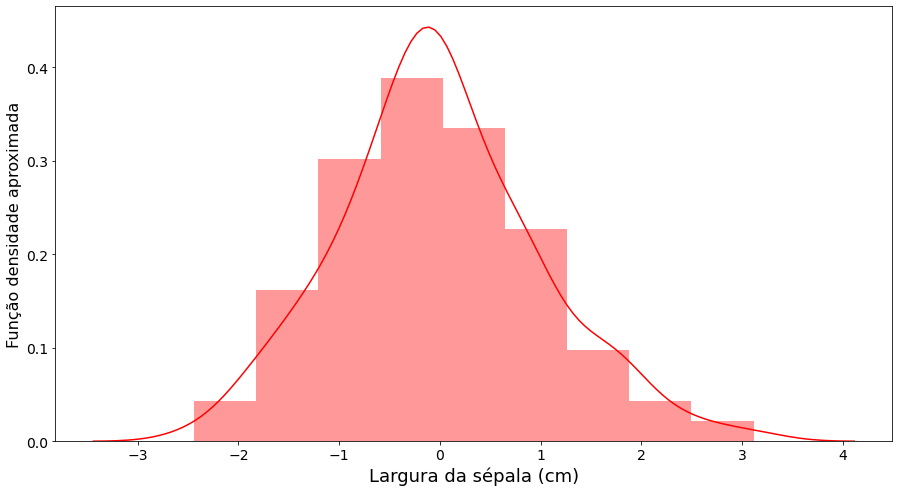

```python
plt.figure(figsize=(15, 8))
x2 = sns.distplot(rescaledX[:,1], bins = 'sturges', color = 'r')
plt.xlabel('Largura da sépala (cm)', fontsize=18)
plt.ylabel('Função densidade aproximada', fontsize=16)
plt.xticks(fontsize=14)
plt.yticks(fontsize=14)
plt.show(True)
```

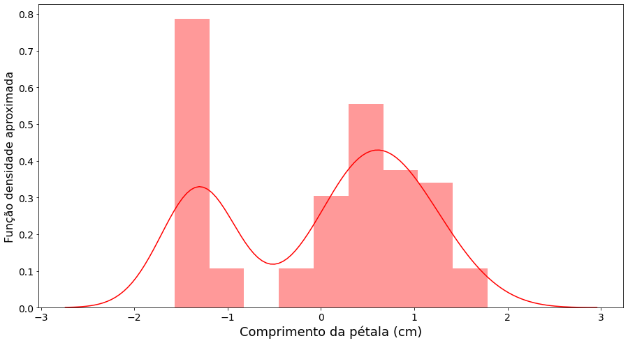

```python
plt.figure(figsize=(15, 8))
x3 = sns.distplot(rescaledX[:,2], bins = 'sturges', color = 'r')
plt.xlabel('Comprimento da pétala (cm)', fontsize=18)
plt.ylabel('Função densidade aproximada', fontsize=16)
plt.xticks(fontsize=14)
plt.yticks(fontsize=14)
plt.show(True)
```

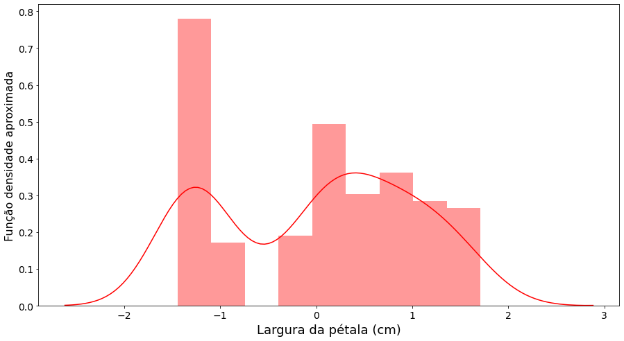

```python
plt.figure(figsize=(15, 8))
x4 = sns.distplot(rescaledX[:,3], bins = 'sturges', color = 'r')
plt.xlabel('Largura da pétala (cm)', fontsize=18)
plt.ylabel('Função densidade aproximada', fontsize=16)
plt.xticks(fontsize=14)
plt.yticks(fontsize=14)
plt.show(True)
```

[figure not shown]

```python
plt.figure(figsize=(20, 8))

x1 = sns.distplot(X_norm[:,0], bins = 'sturges',hist = False, label = "Comprimento sépala")
x2 = sns.distplot(X_norm[:,1], bins = 'sturges',hist = False, label = "Largura sépala")
x3 = sns.distplot(X_norm[:,2], bins = 'sturges',hist = False, label = "Comprimento pétala")
x4 = sns.distplot(X_norm[:,3], bins = 'sturges',hist = False, label = "Largura pétala")

plt.xlabel('Tamanho em cm', fontsize=18)
plt.ylabel('Função densidade aproximada', fontsize=16)
plt.xticks(fontsize=14)
plt.yticks(fontsize=14)
plt.show(True)
```

### 4 - Reamostre os dados da Iris e selecione 10 elementos em cada classe.

Lendo dataset "Iris" no formato CSV, colocando em um dataframe

```python
import pandas as pd

# CSV file
iris2 = pd.read_csv('https://raw.githubusercontent.com/BrenoUSP/SME0828_DataScience/master/Projects/data/iris.csv', header=(0))
```

Dataframes específicos para as espécies

```python
setosa = iris2[iris2.species == 'setosa']
versicolor = iris2[iris2.species == 'versicolor']
virginica = iris2[iris2.species == 'virginica']
```

Pega 10 amostras aleatórias de cada espécie

```python
from random import sample

sampleSetosa = setosa.sample(n = 10, axis = 0)
sampleVersicolor = versicolor.sample(n = 10, axis = 0)
sampleVirginica = virginica.sample(n = 10, axis = 0)
```

#### Amostras aleatórias

Setosa

```python
sampleSetosa
```

|  | sepal_length | sepal_width | petal_length | petal_width | species |
| --- | --- | --- | --- | --- | --- |
| 3 | 4.6 | 3.1 | 1.5 | 0.2 | setosa |
| 26 | 5.0 | 3.4 | 1.6 | 0.4 | setosa |
| 6 | 4.6 | 3.4 | 1.4 | 0.3 | setosa |
| 9 | 4.9 | 3.1 | 1.5 | 0.1 | setosa |
| 35 | 5.0 | 3.2 | 1.2 | 0.2 | setosa |
| 31 | 5.4 | 3.4 | 1.5 | 0.4 | setosa |
| 10 | 5.4 | 3.7 | 1.5 | 0.2 | setosa |
| 32 | 5.2 | 4.1 | 1.5 | 0.1 | setosa |
| 36 | 5.5 | 3.5 | 1.3 | 0.2 | setosa |
| 23 | 5.1 | 3.3 | 1.7 | 0.5 | setosa |

Versicolor

```python
sampleVersicolor
```

|  | sepal_length | sepal_width | petal_length | petal_width | species |
| --- | --- | --- | --- | --- | --- |
| 71 | 6.1 | 2.8 | 4.0 | 1.3 | versicolor |
| 87 | 6.3 | 2.3 | 4.4 | 1.3 | versicolor |
| 73 | 6.1 | 2.8 | 4.7 | 1.2 | versicolor |
| 83 | 6.0 | 2.7 | 5.1 | 1.6 | versicolor |
| 67 | 5.8 | 2.7 | 4.1 | 1.0 | versicolor |
| 76 | 6.8 | 2.8 | 4.8 | 1.4 | versicolor |
| 69 | 5.6 | 2.5 | 3.9 | 1.1 | versicolor |
| 88 | 5.6 | 3.0 | 4.1 | 1.3 | versicolor |
| 98 | 5.1 | 2.5 | 3.0 | 1.1 | versicolor |
| 74 | 6.4 | 2.9 | 4.3 | 1.3 | versicolor |

Virginica

```python
sampleVirginica
```

|  | sepal_length | sepal_width | petal_length | petal_width | species |
| --- | --- | --- | --- | --- | --- |
| 144 | 6.7 | 3.3 | 5.7 | 2.5 | virginica |
| 132 | 6.4 | 2.8 | 5.6 | 2.2 | virginica |
| 116 | 6.5 | 3.0 | 5.5 | 1.8 | virginica |
| 110 | 6.5 | 3.2 | 5.1 | 2.0 | virginica |
| 125 | 7.2 | 3.2 | 6.0 | 1.8 | virginica |
| 135 | 7.7 | 3.0 | 6.1 | 2.3 | virginica |
| 142 | 5.8 | 2.7 | 5.1 | 1.9 | virginica |
| 134 | 6.1 | 2.6 | 5.6 | 1.4 | virginica |
| 145 | 6.7 | 3.0 | 5.2 | 2.3 | virginica |
| 104 | 6.5 | 3.0 | 5.8 | 2.2 | virginica |

### 5 - Monte um boxplot para cada variável dos dados da Iris.

Lê dataset "iris" em um Data Frame

```python
import pandas as pd

iris3 = pd.read_csv('https://raw.githubusercontent.com/BrenoUSP/SME0828_DataScience/master/Projects/data/iris.csv', header=(0))
```

#### Boxplot para cada variável

Os boxplots foram feitos utilizando-se do seaborn com o matplotlib.

Comprimento da pétala

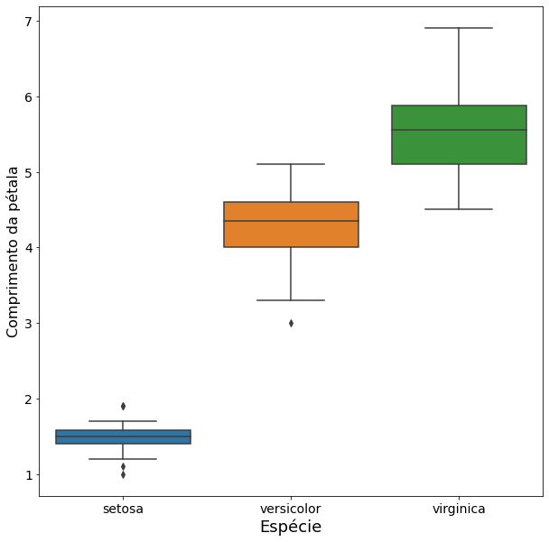

```python
import matplotlib.pyplot as plt
import seaborn as sns

plt.figure(figsize = (10, 10))
sns.boxplot(x = "species", y = "petal_length", data = iris3)
plt.xlabel('Espécie', fontsize = 18)
plt.ylabel('Comprimento da pétala', fontsize = 16)
plt.xticks(fontsize = 14)
plt.yticks(fontsize = 14)
plt.show(True)
```

Largura da pétala

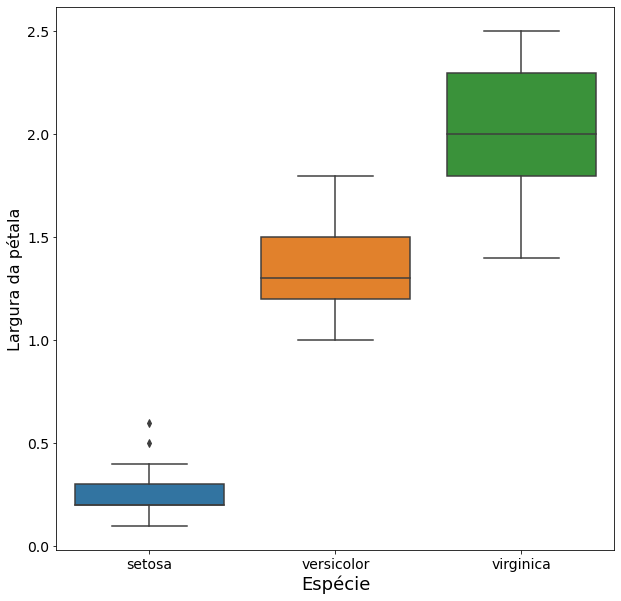

```python
plt.figure(figsize = (10, 10))
sns.boxplot(x = "species", y = "petal_width", data = iris3)
plt.xlabel('Espécie', fontsize = 18)
plt.ylabel('Largura da pétala', fontsize = 16)
plt.xticks(fontsize = 14)
plt.yticks(fontsize = 14)
plt.show(True)
```

Comprimento da sépala

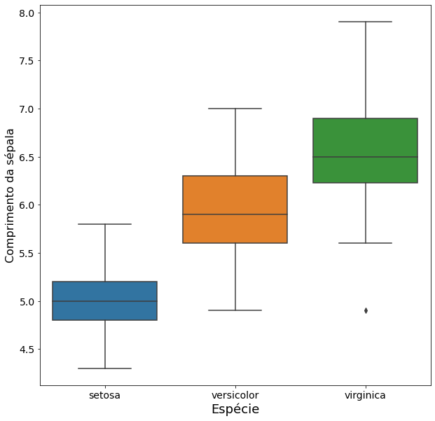

```python
plt.figure(figsize = (10, 10))
sns.boxplot(x = "species", y = "sepal_length", data = iris3)
plt.xlabel('Espécie', fontsize = 18)
plt.ylabel('Comprimento da sépala', fontsize = 16)
plt.xticks(fontsize = 14)
plt.yticks(fontsize = 14)
plt.show(True)
```

Largura da sépala

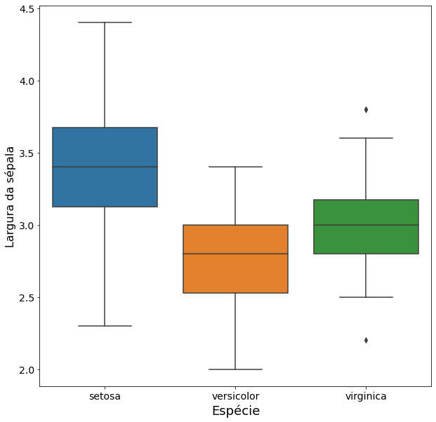

```python
plt.figure(figsize = (10, 10))
sns.boxplot(x = "species", y = "sepal_width", data = iris3)
plt.xlabel('Espécie', fontsize = 18)
plt.ylabel('Largura da sépala', fontsize = 16)
plt.xticks(fontsize = 14)
plt.yticks(fontsize = 14)
plt.show(True)
```

### 6 - Encontre os outliers nos dados das bases Iris e BostonHouse.

```python
# Acessando-se os conjuntos de dados:

data_I = pd.read_csv('https://raw.githubusercontent.com/brenoslivio/SME0828_DataScience/master/Projects/data/iris.csv', header=(0))
data_B = pd.read_csv('https://raw.githubusercontent.com/brenoslivio/SME0828_DataScience/master/Projects/data/BostonHousing.csv', header=(0))
```

Trabalhemos com o conjunto de dados Iris primeiramente. Identifiquemos como outiliers, qualquer observação que seja considerada um outlier para alguma das variáveis de interesse (lembrando-se que a cetegoria "species" não é uma variável quantitativa e assim, não é pertinente para a análise):

```python
data_I_a = data_I.drop(data.columns[[4]], axis=1) # remoção da última coluna (species)

Q1 = data_I_a.quantile(0.25) # primeiro quartil
Q3 = data_I_a.quantile(0.75) # segundo quartil
IQR = Q3 - Q1 # distância interquartil

out = ((data_I_a < (Q1 - 1.5 * IQR)) | (data_I_a > (Q3 + 1.5 * IQR))).any(axis=1) # vetor contendo os valores booleanos
# para cada uma das observações indicando se ele é um outlier (True) ou não (False)

# vetor contendo os outliers para o conjunto de dados Iris
Iris_out = data_I[list(out)]

Iris_out
```

|  | sepal_length | sepal_width | petal_length | petal_width | species |
| --- | --- | --- | --- | --- | --- |
| 15 | 5.7 | 4.4 | 1.5 | 0.4 | setosa |
| 32 | 5.2 | 4.1 | 1.5 | 0.1 | setosa |
| 33 | 5.5 | 4.2 | 1.4 | 0.2 | setosa |
| 60 | 5.0 | 2.0 | 3.5 | 1.0 | versicolor |

Agora, façamos o mesmo para o conjunto BostonHouse:

```python
Q1 = data_B.quantile(0.25) # primeiro quartil
Q3 = data_B.quantile(0.75) # segundo quartil
IQR = Q3 - Q1 # distância interquartil

out = ((data_B < (Q1 - 1.5 * IQR)) | (data_B > (Q3 + 1.5 * IQR))).any(axis=1) # vetor contendo os valores booleanos
# para cada uma das observações indicando se ele é um outlier (True) ou não (False)

# vetor contendo os outliers para o conjunto de dados BostonHouse
Boston_out = data_B[list(out)]

Boston_out
```

|  | crim | zn | indus | chas | nox | rm | age | dis | rad | tax | ptratio | b | lstat | medv |
| --- | --- | --- | --- | --- | --- | --- | --- | --- | --- | --- | --- | --- | --- | --- |
| 18 | 0.80271 | 0.0 | 8.14 | 0 | 0.538 | 5.456 | 36.6 | 3.7965 | 4 | 307 | 21.0 | 288.99 | 11.69 | 20.2 |
| 25 | 0.84054 | 0.0 | 8.14 | 0 | 0.538 | 5.599 | 85.7 | 4.4546 | 4 | 307 | 21.0 | 303.42 | 16.51 | 13.9 |
| 27 | 0.95577 | 0.0 | 8.14 | 0 | 0.538 | 6.047 | 88.8 | 4.4534 | 4 | 307 | 21.0 | 306.38 | 17.28 | 14.8 |
| 32 | 1.38799 | 0.0 | 8.14 | 0 | 0.538 | 5.950 | 82.0 | 3.9900 | 4 | 307 | 21.0 | 232.60 | 27.71 | 13.2 |
| 34 | 1.61282 | 0.0 | 8.14 | 0 | 0.538 | 6.096 | 96.9 | 3.7598 | 4 | 307 | 21.0 | 248.31 | 20.34 | 13.5 |
| ... | ... | ... | ... | ... | ... | ... | ... | ... | ... | ... | ... | ... | ... | ... |
| 477 | 15.02340 | 0.0 | 18.10 | 0 | 0.614 | 5.304 | 97.3 | 2.1007 | 24 | 666 | 20.2 | 349.48 | 24.91 | 12.0 |
| 478 | 10.23300 | 0.0 | 18.10 | 0 | 0.614 | 6.185 | 96.7 | 2.1705 | 24 | 666 | 20.2 | 379.70 | 18.03 | 14.6 |
| 479 | 14.33370 | 0.0 | 18.10 | 0 | 0.614 | 6.229 | 88.0 | 1.9512 | 24 | 666 | 20.2 | 383.32 | 13.11 | 21.4 |
| 489 | 0.18337 | 0.0 | 27.74 | 0 | 0.609 | 5.414 | 98.3 | 1.7554 | 4 | 711 | 20.1 | 344.05 | 23.97 | 7.0 |
| 490 | 0.20746 | 0.0 | 27.74 | 0 | 0.609 | 5.093 | 98.0 | 1.8226 | 4 | 711 | 20.1 | 318.43 | 29.68 | 8.1 |

238 rows × 14 columns